# BST210 Project EDA

# Exploratory Data Analysis

```r
library(tidyverse)
library(stringr)
library(viridisLite) # nice colours
```

## What’s the structure of our data?

```r
dat <- read_csv("data/cancer_reg.csv")
str(dat)
```

```
## spec_tbl_df [3,047 × 34] (S3: spec_tbl_df/tbl_df/tbl/data.frame)
##  $ avgAnnCount            : num [1:3047] 1397 173 102 427 57 ...
##  $ avgDeathsPerYear       : num [1:3047] 469 70 50 202 26 152 97 71 36 1380 ...
##  $ TARGET_deathRate       : num [1:3047] 165 161 175 195 144 ...
##  $ incidenceRate          : num [1:3047] 490 412 350 430 350 ...
##  $ medIncome              : num [1:3047] 61898 48127 49348 44243 49955 ...
##  $ popEst2015             : num [1:3047] 260131 43269 21026 75882 10321 ...
##  $ povertyPercent         : num [1:3047] 11.2 18.6 14.6 17.1 12.5 15.6 23.2 17.8 22.3 13.1 ...
##  $ studyPerCap            : num [1:3047] 499.7 23.1 47.6 342.6 0 ...
##  $ binnedInc              : chr [1:3047] "(61494.5, 125635]" "(48021.6, 51046.4]" "(48021.6, 51046.4]" "(42724.4, 45201]" ...
##  $ MedianAge              : num [1:3047] 39.3 33 45 42.8 48.3 45.4 42.6 51.7 49.3 35.8 ...
##  $ MedianAgeMale          : num [1:3047] 36.9 32.2 44 42.2 47.8 43.5 42.2 50.8 48.4 34.7 ...
##  $ MedianAgeFemale        : num [1:3047] 41.7 33.7 45.8 43.4 48.9 48 43.5 52.5 49.8 37 ...
##  $ Geography              : chr [1:3047] "Kitsap County, Washington" "Kittitas County, Washington" "Klickitat County, Washington" "Lewis County, Washington" ...
##  $ AvgHouseholdSize       : num [1:3047] 2.54 2.34 2.62 2.52 2.34 2.58 2.42 2.24 2.38 2.65 ...
##  $ PercentMarried         : num [1:3047] 52.5 44.5 54.2 52.7 57.8 50.4 54.1 52.7 55.9 50 ...
##  $ PctNoHS18_24           : num [1:3047] 11.5 6.1 24 20.2 14.9 29.9 26.1 27.3 34.7 15.6 ...
##  $ PctHS18_24             : num [1:3047] 39.5 22.4 36.6 41.2 43 35.1 41.4 33.9 39.4 36.3 ...
##  $ PctSomeCol18_24        : num [1:3047] 42.1 64 NA 36.1 40 NA NA 36.5 NA NA ...
##  $ PctBachDeg18_24        : num [1:3047] 6.9 7.5 9.5 2.5 2 4.5 5.8 2.2 1.4 7.1 ...
##  $ PctHS25_Over           : num [1:3047] 23.2 26 29 31.6 33.4 30.4 29.8 31.6 32.2 28.8 ...
##  $ PctBachDeg25_Over      : num [1:3047] 19.6 22.7 16 9.3 15 11.9 11.9 11.3 12 16.2 ...
##  $ PctEmployed16_Over     : num [1:3047] 51.9 55.9 45.9 48.3 48.2 44.1 51.8 40.9 39.5 56.6 ...
##  $ PctUnemployed16_Over   : num [1:3047] 8 7.8 7 12.1 4.8 12.9 8.9 8.9 10.3 9.2 ...
##  $ PctPrivateCoverage     : num [1:3047] 75.1 70.2 63.7 58.4 61.6 60 49.5 55.8 55.5 69.9 ...
##  $ PctPrivateCoverageAlone: num [1:3047] NA 53.8 43.5 40.3 43.9 38.8 35 33.1 37.8 NA ...
##  $ PctEmpPrivCoverage     : num [1:3047] 41.6 43.6 34.9 35 35.1 32.6 28.3 25.9 29.9 44.4 ...
##  $ PctPublicCoverage      : num [1:3047] 32.9 31.1 42.1 45.3 44 43.2 46.4 50.9 48.1 31.4 ...
##  $ PctPublicCoverageAlone : num [1:3047] 14 15.3 21.1 25 22.7 20.2 28.7 24.1 26.6 16.5 ...
##  $ PctWhite               : num [1:3047] 81.8 89.2 90.9 91.7 94.1 ...
##  $ PctBlack               : num [1:3047] 2.595 0.969 0.74 0.783 0.27 ...
##  $ PctAsian               : num [1:3047] 4.822 2.246 0.466 1.161 0.666 ...
##  $ PctOtherRace           : num [1:3047] 1.843 3.741 2.747 1.363 0.492 ...
##  $ PctMarriedHouseholds   : num [1:3047] 52.9 45.4 54.4 51 54 ...
##  $ BirthRate              : num [1:3047] 6.12 4.33 3.73 4.6 6.8 ...
##  - attr(*, "spec")=
##   .. cols(
##   ..   avgAnnCount = col_double(),
##   ..   avgDeathsPerYear = col_double(),
##   ..   TARGET_deathRate = col_double(),
```

[output cut: 18 more lines]

```
##   ..   PctEmployed16_Over = col_double(),
##   ..   PctUnemployed16_Over = col_double(),
##   ..   PctPrivateCoverage = col_double(),
##   ..   PctPrivateCoverageAlone = col_double(),
##   ..   PctEmpPrivCoverage = col_double(),
##   ..   PctPublicCoverage = col_double(),
##   ..   PctPublicCoverageAlone = col_double(),
##   ..   PctWhite = col_double(),
##   ..   PctBlack = col_double(),
##   ..   PctAsian = col_double(),
##   ..   PctOtherRace = col_double(),
##   ..   PctMarriedHouseholds = col_double(),
##   ..   BirthRate = col_double()
##   .. )
##  - attr(*, "problems")=<externalptr>
```

```r
summary(dat)
```

```
##   avgAnnCount      avgDeathsPerYear TARGET_deathRate incidenceRate
##  Min.   :    6.0   Min.   :    3    Min.   : 59.7    Min.   : 201.3
##  1st Qu.:   76.0   1st Qu.:   28    1st Qu.:161.2    1st Qu.: 420.3
##  Median :  171.0   Median :   61    Median :178.1    Median : 453.5
##  Mean   :  606.3   Mean   :  186    Mean   :178.7    Mean   : 448.3
##  3rd Qu.:  518.0   3rd Qu.:  149    3rd Qu.:195.2    3rd Qu.: 480.9
##  Max.   :38150.0   Max.   :14010    Max.   :362.8    Max.   :1206.9
##
##    medIncome        popEst2015       povertyPercent   studyPerCap
##  Min.   : 22640   Min.   :     827   Min.   : 3.20   Min.   :   0.00
##  1st Qu.: 38883   1st Qu.:   11684   1st Qu.:12.15   1st Qu.:   0.00
##  Median : 45207   Median :   26643   Median :15.90   Median :   0.00
##  Mean   : 47063   Mean   :  102637   Mean   :16.88   Mean   : 155.40
##  3rd Qu.: 52492   3rd Qu.:   68671   3rd Qu.:20.40   3rd Qu.:  83.65
##  Max.   :125635   Max.   :10170292   Max.   :47.40   Max.   :9762.31
##
##   binnedInc           MedianAge      MedianAgeMale   MedianAgeFemale
##  Length:3047        Min.   : 22.30   Min.   :22.40   Min.   :22.30
##  Class :character   1st Qu.: 37.70   1st Qu.:36.35   1st Qu.:39.10
##  Mode  :character   Median : 41.00   Median :39.60   Median :42.40
##                     Mean   : 45.27   Mean   :39.57   Mean   :42.15
##                     3rd Qu.: 44.00   3rd Qu.:42.50   3rd Qu.:45.30
##                     Max.   :624.00   Max.   :64.70   Max.   :65.70
##
##   Geography         AvgHouseholdSize PercentMarried   PctNoHS18_24
##  Length:3047        Min.   :0.0221   Min.   :23.10   Min.   : 0.00
##  Class :character   1st Qu.:2.3700   1st Qu.:47.75   1st Qu.:12.80
##  Mode  :character   Median :2.5000   Median :52.40   Median :17.10
##                     Mean   :2.4797   Mean   :51.77   Mean   :18.22
##                     3rd Qu.:2.6300   3rd Qu.:56.40   3rd Qu.:22.70
##                     Max.   :3.9700   Max.   :72.50   Max.   :64.10
##
##    PctHS18_24   PctSomeCol18_24 PctBachDeg18_24   PctHS25_Over
##  Min.   : 0.0   Min.   : 7.10   Min.   : 0.000   Min.   : 7.50
##  1st Qu.:29.2   1st Qu.:34.00   1st Qu.: 3.100   1st Qu.:30.40
##  Median :34.7   Median :40.40   Median : 5.400   Median :35.30
##  Mean   :35.0   Mean   :40.98   Mean   : 6.158   Mean   :34.80
##  3rd Qu.:40.7   3rd Qu.:46.40   3rd Qu.: 8.200   3rd Qu.:39.65
##  Max.   :72.5   Max.   :79.00   Max.   :51.800   Max.   :54.80
##                 NA's   :2285
```

[output cut: 17 more lines]

```
##  Min.   : 2.60          Min.   : 10.20   Min.   : 0.0000   Min.   : 0.0000
##  1st Qu.:14.85          1st Qu.: 77.30   1st Qu.: 0.6207   1st Qu.: 0.2542
##  Median :18.80          Median : 90.06   Median : 2.2476   Median : 0.5498
##  Mean   :19.24          Mean   : 83.65   Mean   : 9.1080   Mean   : 1.2540
##  3rd Qu.:23.10          3rd Qu.: 95.45   3rd Qu.:10.5097   3rd Qu.: 1.2210
##  Max.   :46.60          Max.   :100.00   Max.   :85.9478   Max.   :42.6194
##
##   PctOtherRace     PctMarriedHouseholds   BirthRate
##  Min.   : 0.0000   Min.   :22.99        Min.   : 0.000
##  1st Qu.: 0.2952   1st Qu.:47.76        1st Qu.: 4.521
##  Median : 0.8262   Median :51.67        Median : 5.381
##  Mean   : 1.9835   Mean   :51.24        Mean   : 5.640
##  3rd Qu.: 2.1780   3rd Qu.:55.40        3rd Qu.: 6.494
##  Max.   :41.9303   Max.   :78.08        Max.   :21.326
##
```

```r
ed <- read_csv("data/Education.csv")
states <- read_csv("data/50_states.csv") %>%
    add_row(State="District of Columbia", Abbr="DC", `State Capital`="Washington", Region="East")
```

```r
# get county names
dat <- dat %>%
    mutate(county_name = str_split(Geography, ",") %>% map_chr(., 1))%>%
    mutate(state = str_extract(Geography, "[^,]+$")) %>% # regex to select everything after ','
    mutate(state = str_trim(state)) %>%
    left_join(states, by=c("state" = "State")) %>%
    filter(county_name != "Valdez-Cordova Census Area")

Encoding(dat$county_name) <- "UTF-8"
dat$county_name <- iconv(dat$county_name, "UTF-8", "UTF-8", sub='')
dat <- dat %>%
    mutate(county_name = ifelse(county_name == "Doa Ana County", "Dona Ana County", county_name))

# get education stats from 2016-2020 https://www.ers.usda.gov/data-products/county-level-data-sets/download-data/
ed <- ed %>%
    filter(grepl("2016", Attribute)) %>%
    rename(county_name = `Area name`) %>%
    pivot_wider(names_from = Attribute, values_from = Value)  %>%
    mutate(county_name = case_when(county_name == "La Salle County" & State != "TX" ~ "LaSalle County",
                                   county_name == "La Salle Parish" ~ "LaSalle Parish",
                                   TRUE ~ county_name))

dat <- ed %>%
    right_join(dat, by=c("county_name", "State" = "Abbr")) %>%
    distinct()
```

## How much missing data is there?

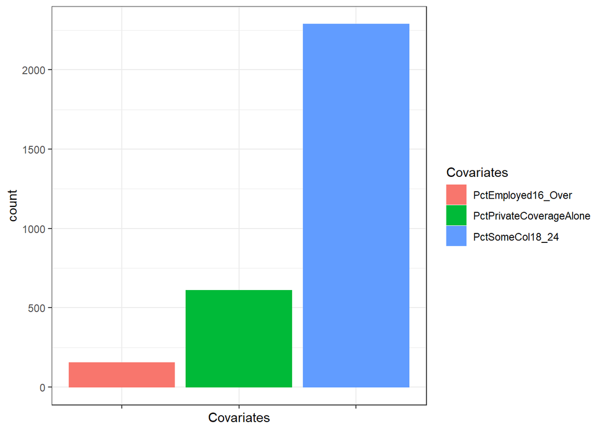

```r
no_geodat <- dat %>% select(-c("Geography", "State Capital", "Region", "state", "State", "county_name", "binnedInc")) # no missing counties
no_geodat[!complete.cases(no_geodat),] %>%  # keep rows with NAs
    pivot_longer(colnames(no_geodat), names_to = "Covariates", values_to = "Values") %>% # pivot into long table
    filter(is.na(Values)) %>% # filter out all the non-na's
    ggplot(aes(x = Covariates)) +
    geom_bar(position = "dodge", aes(col = Covariates, fill = Covariates)) +
    theme_bw() +
    # scale_fill_viridis_d() +
    # scale_color_viridis_d() +
    theme(axis.text.x = element_blank())
```

Interestingly, there is some missing data in the reporting of county employment for residents age 16 and over. We observe more missing data in percentages of county residents with only private healthcare coverage, and missing data in the majority of counties for reports of the percent of county residents between 18 and 24 years old with with some college as their highest attained education. One hypothesis for why there may be a large amount of missing data in educational reporting for 18 to 24 year olds with some college may be because some counties may not have high emphasis on higher education and many individuals in this age range that are pursuing college will probably be in more college-oriented counties.

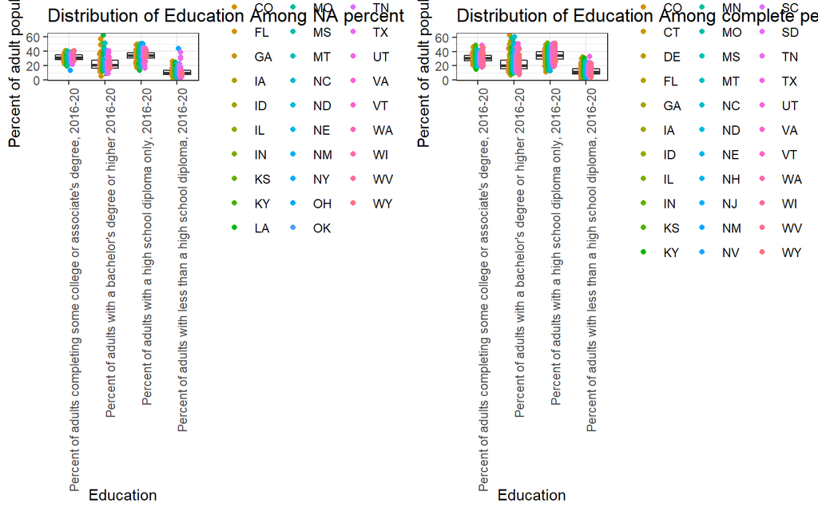

```r
# NAs grouped by education
p1a <- dat[!complete.cases(dat),] %>%  # keep rows with NAs
    pivot_longer(colnames(ed)[8:11], names_to = "Education", values_to = "Values") %>% # pivot into long table
    filter(is.na(PctEmployed16_Over)) %>% # filter out all the non-na's
    ggplot(aes(x = Education, y = Values)) +
    geom_boxplot(show.legend = F, outlier.shape = NA) +
    geom_point(aes(col = State), position = position_jitterdodge(jitter.width=0, dodge.width = 0.3)) +
    theme_bw() +
    theme(axis.text.x = element_text(angle = 90, hjust=1)) +
    labs(y = "Percent of adult population", title = "Distribution of Education Among NA percent employed 16 and over")
    # scale_fill_viridis_d() +
    # scale_color_viridis_d() +

p1b <- dat[complete.cases(dat),] %>%  # keep rows with NAs
    pivot_longer(colnames(ed)[8:11], names_to = "Education", values_to = "Values") %>% # pivot into long table
    filter(!is.na(PctEmployed16_Over)) %>% # filter out all the non-na's
    ggplot(aes(x = Education, y = Values)) +
    geom_boxplot(show.legend = F, outlier.shape = NA) +
    geom_point(aes(col = State), position = position_jitterdodge(jitter.width=0, dodge.width = 0.3)) +
    theme_bw() +
    theme(axis.text.x = element_text(angle = 90, hjust=1)) +
    labs(y = "Percent of adult population", title = "Distribution of Education Among complete percent employed 16 and over")

gridExtra::grid.arrange(p1a, p1b, ncol = 2)
```

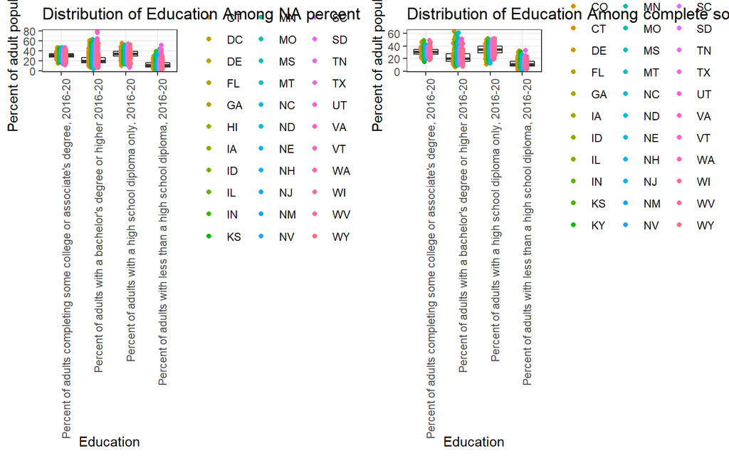

```r
# NAs grouped by education
p1a <- dat[!complete.cases(dat),] %>%  # keep rows with NAs
    pivot_longer(colnames(ed)[8:11], names_to = "Education", values_to = "Values") %>% # pivot into long table
    filter(is.na(PctSomeCol18_24)) %>% # filter out all the non-na's
    ggplot(aes(x = Education, y = Values)) +
    geom_boxplot(show.legend = F, outlier.shape = NA) +
    geom_point(aes(col = State), position = position_jitterdodge(jitter.width=0, dodge.width = 0.3)) +
    theme_bw() +
    theme(axis.text.x = element_text(angle = 90, hjust=1)) +
    labs(y = "Percent of adult population", title = "Distribution of Education Among NA percent some college education 18-24")
    # scale_fill_viridis_d() +
    # scale_color_viridis_d() +

p1b <- dat[complete.cases(dat),] %>%  # keep rows with NAs
    pivot_longer(colnames(ed)[8:11], names_to = "Education", values_to = "Values") %>% # pivot into long table
    filter(!is.na(PctSomeCol18_24)) %>% # filter out all the non-na's
    ggplot(aes(x = Education, y = Values)) +
    geom_boxplot(show.legend = F, outlier.shape = NA) +
    geom_point(aes(col = State), position = position_jitterdodge(jitter.width=0, dodge.width = 0.3)) +
    theme_bw() +
    theme(axis.text.x = element_text(angle = 90, hjust=1)) +
    labs(y = "Percent of adult population", title = "Distribution of Education Among complete some college education 18-24")

gridExtra::grid.arrange(p1a, p1b, ncol = 2)
```

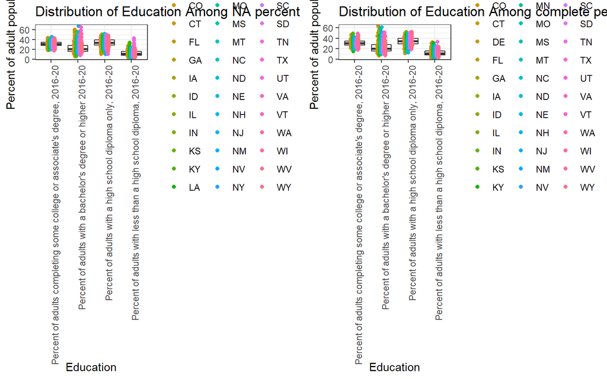

```r
# NAs grouped by education
p1a <- dat[!complete.cases(dat),] %>%  # keep rows with NAs
    pivot_longer(colnames(ed)[8:11], names_to = "Education", values_to = "Values") %>% # pivot into long table
    filter(is.na(PctPrivateCoverageAlone)) %>% # filter out all the non-na's
    ggplot(aes(x = Education, y = Values)) +
    geom_boxplot(show.legend = F, outlier.shape = NA) +
    geom_point(aes(col = State), position = position_jitterdodge(jitter.width=0, dodge.width = 0.3)) +
    theme_bw() +
    theme(axis.text.x = element_text(angle = 90, hjust=1)) +
    labs(y = "Percent of adult population", title = "Distribution of Education Among NA percent alone private coverage")
    # scale_fill_viridis_d() +
    # scale_color_viridis_d() +

p1b <- dat[complete.cases(dat),] %>%  # keep rows with NAs
    pivot_longer(colnames(ed)[8:11], names_to = "Education", values_to = "Values") %>% # pivot into long table
    filter(!is.na(PctPrivateCoverageAlone)) %>% # filter out all the non-na's
    ggplot(aes(x = Education, y = Values)) +
    geom_boxplot(show.legend = F, outlier.shape = NA) +
    geom_point(aes(col = State), position = position_jitterdodge(jitter.width=0, dodge.width = 0.3)) +
    theme_bw() +
    theme(axis.text.x = element_text(angle = 90, hjust=1)) +
    labs(y = "Percent of adult population", title = "Distribution of Education Among complete percent alone private coverage")

gridExtra::grid.arrange(p1a, p1b, ncol = 2)
```

```r
colMeans(is.na(no_geodat))*100
```

```
##                                                                FIPS Code
##                                                                 0.000000
##                                 Less than a high school diploma, 2016-20
##                                                                 0.000000
##                                        High school diploma only, 2016-20
##                                                                 0.000000
##                              Some college or associate's degree, 2016-20
##                                                                 0.000000
##                                     Bachelor's degree or higher, 2016-20
##                                                                 0.000000
##          Percent of adults with less than a high school diploma, 2016-20
##                                                                 0.000000
##               Percent of adults with a high school diploma only, 2016-20
##                                                                 0.000000
## Percent of adults completing some college or associate's degree, 2016-20
##                                                                 0.000000
##             Percent of adults with a bachelor's degree or higher 2016-20
##                                                                 0.000000
##                                                              avgAnnCount
##                                                                 0.000000
##                                                         avgDeathsPerYear
##                                                                 0.000000
##                                                         TARGET_deathRate
##                                                                 0.000000
##                                                            incidenceRate
##                                                                 0.000000
##                                                                medIncome
##                                                                 0.000000
##                                                               popEst2015
##                                                                 0.000000
##                                                           povertyPercent
##                                                                 0.000000
##                                                              studyPerCap
##                                                                 0.000000
##                                                                MedianAge
##                                                                 0.000000
##                                                            MedianAgeMale
##                                                                 0.000000
##                                                          MedianAgeFemale
##                                                                 0.000000
```

[output cut: 27 more lines]

```
##                                                                 0.000000
##                                                   PctPublicCoverageAlone
##                                                                 0.000000
##                                                                 PctWhite
##                                                                 0.000000
##                                                                 PctBlack
##                                                                 0.000000
##                                                                 PctAsian
##                                                                 0.000000
##                                                             PctOtherRace
##                                                                 0.000000
##                                                     PctMarriedHouseholds
##                                                                 0.000000
##                                                                BirthRate
##                                                                 0.000000
```

```r
ed_missing <- setdiff(unique(ed$county_name), unique(dat$county_name))
filter(ed, county_name %in% ed_missing)
```

| FIPS Code | State | county_name | Less than a high school diploma, 2016-20 | High school diploma only, 2016-20 | Some college or associate's degree, 2016-20 | Bachelor's degree or higher, 2016-20 | Percent of adults with less than a high school diploma, 2016-20 | Percent of adults with a high school diploma only, 2016-20 | Percent of adults completing some college or associate's degree, 2016-20 | Percent of adults with a bachelor's degree or higher 2016-20 |
| --- | --- | --- | --- | --- | --- | --- | --- | --- | --- | --- |
| 0 | US | United States | 25562680 | 59421420 | 64496416 | 73356320 | 11.471478 | 26.66589 | 28.943336 | 32.919296 |
| 1000 | AL | Alabama | 438947 | 1014342 | 1013673 | 877044 | 13.126382 | 30.33314 | 30.313133 | 26.227345 |
| 1035 | AL | Conecuh County | 1328 | 4125 | 2152 | 1221 | 15.046453 | 46.73691 | 24.382505 | 13.834126 |
| 2000 | AK | Alaska | 33176 | 137486 | 167807 | 144967 | 6.862542 | 28.43934 | 34.711315 | 29.986803 |
| 2013 | AK | Aleutians East Borough | 354 | 1077 | 777 | 438 | 13.378685 | 40.70295 | 29.365080 | 16.553288 |
| 2060 | AK | Bristol Bay Borough | 35 | 168 | 213 | 145 | 6.238859 | 29.94652 | 37.967915 | 25.846703 |
| 2063 | AK | Chugach Census Area, Alaska | 204 | 1126 | 1994 | 1362 | 4.353393 | 24.02902 | 42.552284 | 29.065300 |
| 2066 | AK | Copper River Census Area, Alaska | 86 | 650 | 551 | 593 | 4.574468 | 34.57447 | 29.308510 | 31.542553 |
| 2068 | AK | Denali Borough | 42 | 563 | 531 | 730 | 2.250804 | 30.17149 | 28.456593 | 39.121113 |
| 2105 | AK | Hoonah-Angoon Census Area | 105 | 635 | 662 | 342 | 6.020642 | 36.41055 | 37.958717 | 19.610092 |

[output cut: 181 more lines]

```r
dat_missing <- setdiff(unique(dat$county_name), unique(ed$county_name))
filter(dat, county_name %in% dat_missing)
```

| FIPS Code | State | county_name | Less than a high school diploma, 2016-20 | High school diploma only, 2016-20 | Some college or associate's degree, 2016-20 | Bachelor's degree or higher, 2016-20 | Percent of adults with less than a high school diploma, 2016-20 | Percent of adults with a high school diploma only, 2016-20 | Percent of adults completing some college or associate's degree, 2016-20 | Percent of adults with a bachelor's degree or higher 2016-20 | avgAnnCount | avgDeathsPerYear | TARGET_deathRate | incidenceRate | medIncome | popEst2015 | povertyPercent | studyPerCap | binnedInc | MedianAge | MedianAgeMale | MedianAgeFemale | Geography | AvgHouseholdSize | PercentMarried | PctNoHS18_24 | PctHS18_24 | PctSomeCol18_24 | PctBachDeg18_24 | … |
| --- | --- | --- | --- | --- | --- | --- | --- | --- | --- | --- | --- | --- | --- | --- | --- | --- | --- | --- | --- | --- | --- | --- | --- | --- | --- | --- | --- | --- | --- | --- |

Here we show some difference in county representation within our two integrated cancer trial and socioeconomic dataset with a dataset of education attainment by county. Notably, a large difference in the counties from both datasets is the inclusino of Puerto Rico. While the education dataset includes Puerto Rico, the cancer trial data set does not. This means this missing data is **MAR** for our primary inference since it depends on a covariate *State* (or **MNAR** for our secondary as county is an outcome), however we will consider our analysis without Puerto Rico as it is a unique situation and not localized to the North American land mass. Other missing cancer data are at the county level, not found in the education dataset, similarly, as we are focused on the cancer data, we will disregard these education data (as we have education data for all cancer-statistic counties we have).

## Exploring data patterns and modeling

```r
#pairs(dat %>% select(where(is.numeric)))
```

### Look at the state-wide view

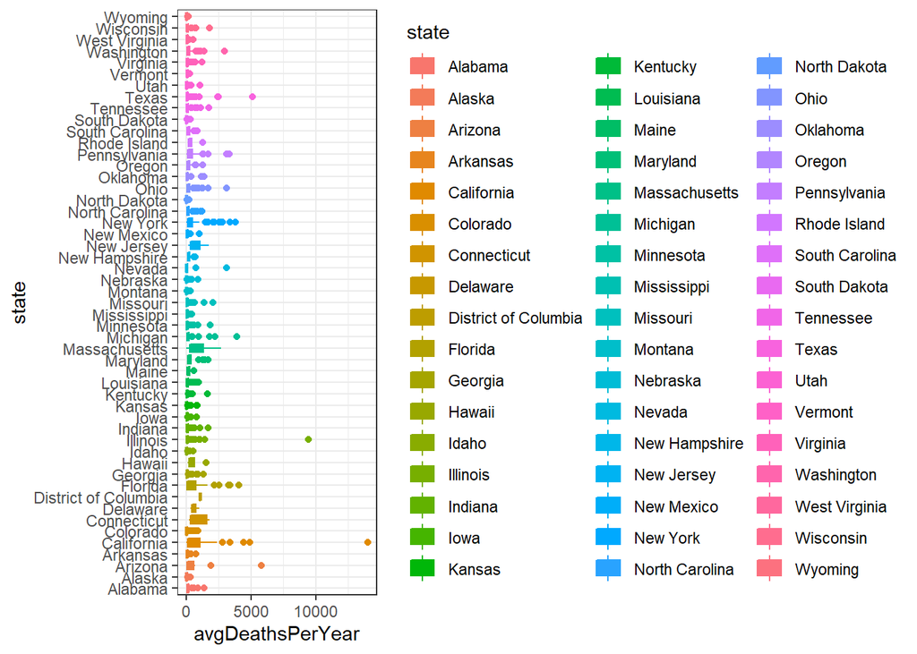

```r
dat %>%
    ggplot(aes(x = state, y = avgDeathsPerYear, colour = state, fill = state)) +
    geom_boxplot() +
    theme_bw() +
    coord_flip()
```

# Check-in 2

## 4. Missing data

### a.

Overall, our data contains 19.9869% data missing from private health insurance coverage alone, 4.9885%% data missing from percent of individuals 16 or over that are employed, and 74.9918% data missing from percent of individuals who have some college education between ages of 18 to 24.

We believe the missing private health insurance data is *MAR* due to the fact that some other counties in the same state have this data, and the individual who created this data set did not include the processing scripts for insurance data. This leads me to believe the most probable reason for these missing data are due to not carefully checking for missing data. Due to it being 19.9869% missing, We don’t believe we can simply disregard this data, as such we will need to formally address it via some missing data methods.

With similar reasoning, we believe the 4.9885% missing data from percentage of employed individuals 16 or over and 74.9918% missing data from percentage of individuals with some college education between ages 18 to 24 are also *MAR*. Especially with the college education, we found external census data on the county-level providing education data, reinforcing the belief that the original data was lost through data processing, perhaps due to issues like attributes not matching on data set joins.

### b.

For the 4.9885% missing data from percentage of employed individuals 16 or over and 74.9918% missing data from percentage of individuals with some college education between ages 18 to 24, we will drop the missing data. This is because the employement data is still under the 5% threshold by rule-of-thumb, and should not have a huge impact on biasing our resulting estimates. Due to the large amount of missing data in the education attribute, we will simply drop that attribute, as we do not believe we would be able to get a meaningful analysis using it anyways (with or without missing data methods).

For the 19.9869% of missing insurance data, we will perform a sensitivity analysis. That is, viewing models under complete cases, under imputation (mean, EM, random forest), and under other missing data methods such as inverse proportional weighting. We will also explore these methods conditional on the states, as we believe that counties within a state are more likely to be similar to each other as they are geographically similar, and share state-level policies, which would likely influence the socioeconomic attributes within a county.

## 5. Modelling Approches

### a. Fitting an linear model

Linear regression models hold a special position in the world of statistics, as it is one of the oldest, and the most tried-and-true method of models. For the purpose of this project, linear models, both GAM and multiple regression, serve as an valuable and important introduction to the exploration of the dataset. Our data set contains information on the socioeconomic status, lung cancer death rate, demographic, etc. of US counties. If we view cancer death rate as an continuous variable outcome, we can most certainly derive very useful information on the relationship between social factors and the cancer death rate within different US counties.

Our main interest in the data set is whether we can derive some useful relationship between the social-economic status of US counties, and their lung cancer-related death rate. In our data set, the lung cancer-related death rate is specifically defined to be the Mean per 100,000 citizen lung cancer mortality over the data collection period (2010 -2016, with exception of the additional education data that was collected in 2020). Before we formally think about the model structure, we should first define our set of social economic status indicators.

Several co-variates from our data is specifically useful in defining the social-economic status of a region. First, median income is a key predictor as it is often used by economists in their evaluation of the wealthiness of a region. Second, median age is an important demographic descriptor in two sense. Median age can describe both the likelihood to get lung cancer (older people are more susceptible to cancer) and the wealth level of the county (older people are more likely to be richer). Third, percentage of white people in each county could also be useful in defining the social-economic status of the region, as historically, white neighborhoods are more likely to be better funded, and thus result in better healthcare conditions. With these indicators in mind, let’s first explore a multiple linear regression model.

#### Model assumptions:

Since our data are sourced from census, and goverment sources, we have reason to believe that each predictor variables following the central limiting theorem (each covariate entry is the mean over multiple years samples), and the LINE assumptions should be met.

#### data transformation and cleaning:

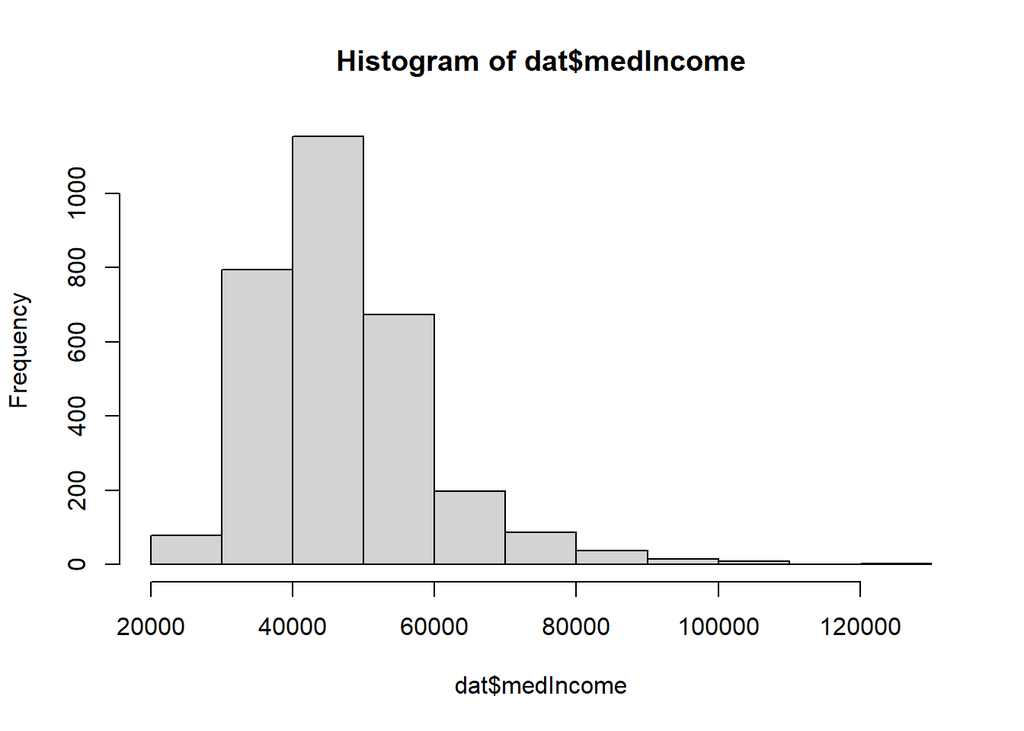

```r
hist(dat$medIncome)
```

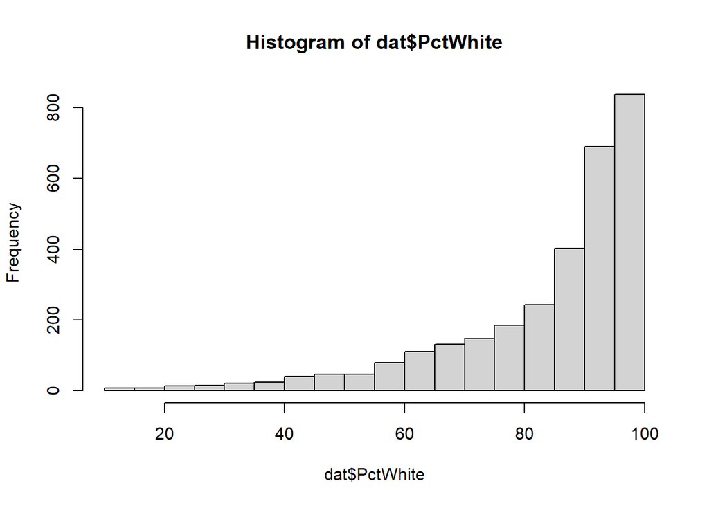

```r
hist(dat$PctWhite)
```

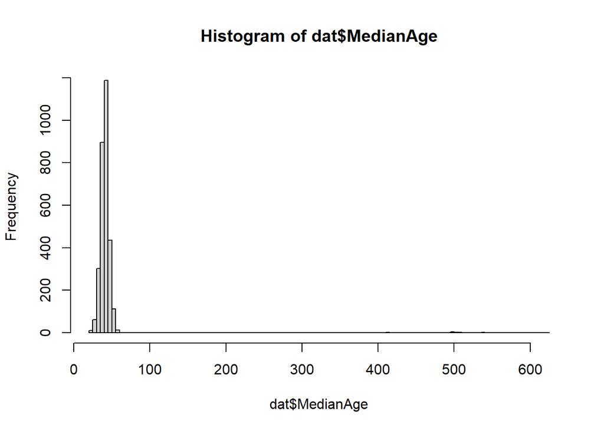

```r
hist(dat$MedianAge, breaks = 100)
```

we see that there are some insanely high median age here. These has to be errors in data collection or imputing process as it is improbable to have median ages that high. let’s remove these rows of data for now.

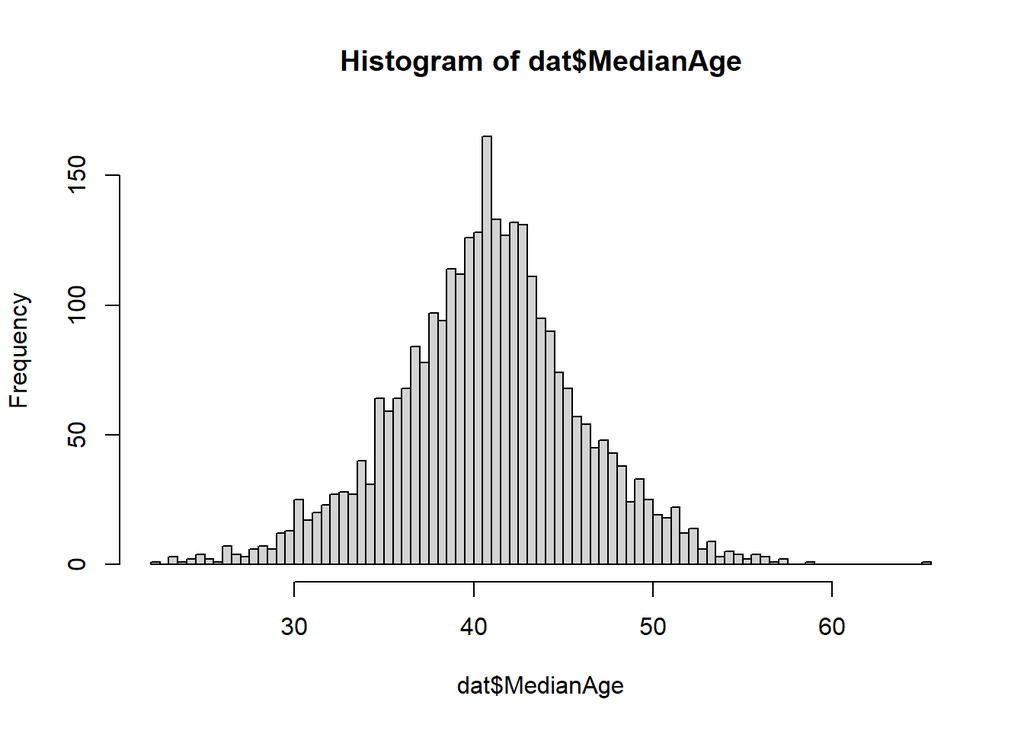

```r
dat = dat %>% filter(MedianAge <= 100)

hist(dat$MedianAge, breaks = 100)
```

The other two variables are skewed, but they should be workable. I am not normalizing the income data as the interpretability is a bit better this way.

#### model fitting:

```r
mod1 = lm(data = dat, TARGET_deathRate ~ medIncome + MedianAge + PctWhite)
summary(mod1)
```

```
##
## Call:
## lm(formula = TARGET_deathRate ~ medIncome + MedianAge + PctWhite,
##     data = dat)
##
## Residuals:
##      Min       1Q   Median       3Q      Max
## -123.117  -14.061    0.904   15.057  175.883
##
## Coefficients:
##               Estimate Std. Error t value Pr(>|t|)
## (Intercept)  2.411e+02  4.250e+00  56.735  < 2e-16 ***
## medIncome   -9.492e-04  3.889e-05 -24.409  < 2e-16 ***
## MedianAge   -7.100e-02  9.591e-02  -0.740    0.459
## PctWhite    -1.785e-01  3.065e-02  -5.823  6.4e-09 ***
## ---
## Signif. codes:  0 '***' 0.001 '**' 0.01 '*' 0.05 '.' 0.1 ' ' 1
##
## Residual standard error: 24.89 on 3013 degrees of freedom
## Multiple R-squared:  0.1954, Adjusted R-squared:  0.1946
## F-statistic:   244 on 3 and 3013 DF,  p-value: < 2.2e-16
```

Based on the model summary, we can see that median age is not a significant predictor of lung cancer death rate itself, which is a bit surprising based on previous assumptions. However, it could act still act as a confounder or effect modifier for our model. At the same time, it is good to see that both median income and the percentage of white population within a county is significantly correlated with lung cancer death rate. However, as previously illustrated, median age could also be a confounder to median income. Thus, let’s quickly do some tests on whether median age is a confounder here.

```r
mod1.1 = lm(data = dat, TARGET_deathRate ~ medIncome + PctWhite)
summary(mod1.1)
```

```
##
## Call:
## lm(formula = TARGET_deathRate ~ medIncome + PctWhite, data = dat)
##
## Residuals:
##      Min       1Q   Median       3Q      Max
## -122.987  -14.167    0.874   15.145  175.870
##
## Coefficients:
##               Estimate Std. Error t value Pr(>|t|)
## (Intercept)  2.387e+02  2.748e+00  86.894  < 2e-16 ***
## medIncome   -9.436e-04  3.813e-05 -24.746  < 2e-16 ***
## PctWhite    -1.876e-01  2.806e-02  -6.686 2.73e-11 ***
## ---
## Signif. codes:  0 '***' 0.001 '**' 0.01 '*' 0.05 '.' 0.1 ' ' 1
##
## Residual standard error: 24.89 on 3014 degrees of freedom
## Multiple R-squared:  0.1953, Adjusted R-squared:  0.1947
## F-statistic: 365.7 on 2 and 3014 DF,  p-value: < 2.2e-16
```

```r
anova(mod1.1, mod1)
```

|  | Res.Df | RSS | Df | Sum of Sq | F | Pr(>F) |
| --- | --- | --- | --- | --- | --- | --- |
| 1 | 3014 | 1867102 | NA | NA | NA | NA |
| 2 | 3013 | 1866763 | 1 | 339.5708 | 0.5480754 | 0.4591628 |

We see that removing median age doesn’t affect the coefficients of the two other covariates at all. And LRT result supports this finding.

```r
mod1.2 = lm(data = dat, TARGET_deathRate ~ medIncome + PctWhite + MedianAge + medIncome*MedianAge)
summary(mod1.2)
```

```
##
## Call:
## lm(formula = TARGET_deathRate ~ medIncome + PctWhite + MedianAge +
##     medIncome * MedianAge, data = dat)
##
## Residuals:
##      Min       1Q   Median       3Q      Max
## -123.331  -13.843    0.929   14.955  175.902
##
## Coefficients:
##                       Estimate Std. Error t value Pr(>|t|)
## (Intercept)          2.012e+02  1.625e+01  12.379  < 2e-16 ***
## medIncome           -7.301e-05  3.464e-04  -0.211   0.8331
## PctWhite            -1.806e-01  3.064e-02  -5.894  4.2e-09 ***
## MedianAge            9.390e-01  4.082e-01   2.301   0.0215 *
## medIncome:MedianAge -2.213e-05  8.693e-06  -2.546   0.0110 *
## ---
## Signif. codes:  0 '***' 0.001 '**' 0.01 '*' 0.05 '.' 0.1 ' ' 1
##
## Residual standard error: 24.87 on 3012 degrees of freedom
## Multiple R-squared:  0.1972, Adjusted R-squared:  0.1961
## F-statistic: 184.9 on 4 and 3012 DF,  p-value: < 2.2e-16
```

```r
anova(mod1.2, mod1)
```

|  | Res.Df | RSS | Df | Sum of Sq | F | Pr(>F) |
| --- | --- | --- | --- | --- | --- | --- |
| 1 | 3012 | 1862754 | NA | NA | NA | NA |
| 2 | 3013 | 1866763 | -1 | -4008.256 | 6.481191 | 0.0109516 |

```r
mod1.3 = lm(data = dat, TARGET_deathRate ~ medIncome + PctWhite + MedianAge + PctWhite*MedianAge)
summary(mod1.3)
```

```
##
## Call:
## lm(formula = TARGET_deathRate ~ medIncome + PctWhite + MedianAge +
##     PctWhite * MedianAge, data = dat)
##
## Residuals:
##      Min       1Q   Median       3Q      Max
## -123.122  -14.063    0.896   15.064  175.865
##
## Coefficients:
##                      Estimate Std. Error t value Pr(>|t|)
## (Intercept)         2.400e+02  1.824e+01  13.160   <2e-16 ***
## medIncome          -9.493e-04  3.890e-05 -24.401   <2e-16 ***
## PctWhite           -1.653e-01  2.123e-01  -0.779    0.436
## MedianAge          -4.166e-02  4.759e-01  -0.088    0.930
## PctWhite:MedianAge -3.438e-04  5.461e-03  -0.063    0.950
## ---
## Signif. codes:  0 '***' 0.001 '**' 0.01 '*' 0.05 '.' 0.1 ' ' 1
##
## Residual standard error: 24.9 on 3012 degrees of freedom
## Multiple R-squared:  0.1954, Adjusted R-squared:  0.1944
## F-statistic: 182.9 on 4 and 3012 DF,  p-value: < 2.2e-16
```

```r
anova(mod1.3, mod1)
```

|  | Res.Df | RSS | Df | Sum of Sq | F | Pr(>F) |
| --- | --- | --- | --- | --- | --- | --- |
| 1 | 3012 | 1866760 | NA | NA | NA | NA |
| 2 | 3013 | 1866763 | -1 | -2.456493 | 0.003963529 | 0.9498053 |

```r
mod1.4 = lm(data = dat, TARGET_deathRate ~ medIncome + PctWhite + PctBlack + PctAsian + PctOtherRace)
summary(mod1.4)
```

```
##
## Call:
## lm(formula = TARGET_deathRate ~ medIncome + PctWhite + PctBlack +
##     PctAsian + PctOtherRace, data = dat)
##
## Residuals:
##      Min       1Q   Median       3Q      Max
## -118.383  -13.918    0.866   14.279  174.216
##
## Coefficients:
##                Estimate Std. Error t value Pr(>|t|)
## (Intercept)   2.364e+02  5.931e+00  39.869  < 2e-16 ***
## medIncome    -8.450e-04  4.302e-05 -19.640  < 2e-16 ***
## PctWhite     -1.917e-01  6.064e-02  -3.161  0.00159 **
## PctBlack      1.204e-01  6.406e-02   1.879  0.06033 .
## PctAsian     -2.622e-01  2.130e-01  -1.231  0.21854
## PctOtherRace -1.395e+00  1.414e-01  -9.865  < 2e-16 ***
## ---
## Signif. codes:  0 '***' 0.001 '**' 0.01 '*' 0.05 '.' 0.1 ' ' 1
##
## Residual standard error: 24.33 on 3011 degrees of freedom
## Multiple R-squared:  0.2317, Adjusted R-squared:  0.2305
## F-statistic: 181.7 on 5 and 3011 DF,  p-value: < 2.2e-16
```

We see that the adjusted R-squared value of model 1.4 is higher than model 1.3 and it is beneficial to include a fuller description of the racial distribution. However, we can also see that the Asian and Black percentages are not very significant. By definition, there should be some interactions between these percentages, and it is worth it to check it out.

```r
cor(dat$PctAsian, dat$PctWhite)
```

```
## [1] -0.2658648
```

```r
cor(dat$PctBlack, dat$PctWhite)
```

```
## [1] -0.8312116
```

```r
cor(dat$PctOtherRace, dat$PctWhite)
```

```
## [1] -0.2331931
```

We see that the value of PctBlack and PctWhite are strongly negatively correlated, and the other two percentages are weakly correlated. Thus, we should remove PctBlack from the model to reduce colinearity.

```r
mod1.5 = lm(data = dat, TARGET_deathRate ~ medIncome + PctWhite + PctAsian + PctOtherRace)
summary(mod1.5)
```

```
##
## Call:
## lm(formula = TARGET_deathRate ~ medIncome + PctWhite + PctAsian +
##     PctOtherRace, data = dat)
##
## Residuals:
##      Min       1Q   Median       3Q      Max
## -118.382  -13.873    0.839   14.226  174.620
##
## Coefficients:
##                Estimate Std. Error t value Pr(>|t|)
## (Intercept)   2.463e+02  2.763e+00  89.160   <2e-16 ***
## medIncome    -8.482e-04  4.301e-05 -19.723   <2e-16 ***
## PctWhite     -2.905e-01  3.025e-02  -9.604   <2e-16 ***
## PctAsian     -3.827e-01  2.032e-01  -1.883   0.0598 .
## PctOtherRace -1.495e+00  1.310e-01 -11.413   <2e-16 ***
## ---
## Signif. codes:  0 '***' 0.001 '**' 0.01 '*' 0.05 '.' 0.1 ' ' 1
##
## Residual standard error: 24.34 on 3012 degrees of freedom
## Multiple R-squared:  0.2308, Adjusted R-squared:  0.2298
## F-statistic:   226 on 4 and 3012 DF,  p-value: < 2.2e-16
```

```r
anova(mod1.5, mod1.1)
```

|  | Res.Df | RSS | Df | Sum of Sq | F | Pr(>F) |
| --- | --- | --- | --- | --- | --- | --- |
| 1 | 3012 | 1784592 | NA | NA | NA | NA |
| 2 | 3014 | 1867102 | -2 | -82510.2 | 69.62956 | 2.744758e-30 |

After removing the PctBlack covariate, we see that there is a significant increase in adjusted R-squared value to mod1.1(baseline) and LRT results suggest the models are significantly different from each other. Let’s take another look at the median income covariates again. My main interest here is that whether a quadratic term would benefit our model, as a income could have diminishing return effect on lung cancer prevention/death rate.

```r
mod1.6 = lm(data = dat, TARGET_deathRate ~ medIncome)
summary(mod1.6)
```

```
##
## Call:
## lm(formula = TARGET_deathRate ~ medIncome, data = dat)
##
## Residuals:
##      Min       1Q   Median       3Q      Max
## -124.962  -14.433    0.937   15.098  177.402
##
## Coefficients:
##               Estimate Std. Error t value Pr(>|t|)
## (Intercept)  2.250e+02  1.840e+00  122.29   <2e-16 ***
## medIncome   -9.856e-04  3.788e-05  -26.02   <2e-16 ***
## ---
## Signif. codes:  0 '***' 0.001 '**' 0.01 '*' 0.05 '.' 0.1 ' ' 1
##
## Residual standard error: 25.07 on 3015 degrees of freedom
## Multiple R-squared:  0.1833, Adjusted R-squared:  0.1831
## F-statistic: 676.9 on 1 and 3015 DF,  p-value: < 2.2e-16
```

```r
mod1.6.1 = lm(data = dat, TARGET_deathRate ~ medIncome + I(medIncome ^2))
summary(mod1.6.1)
```

```
##
## Call:
## lm(formula = TARGET_deathRate ~ medIncome + I(medIncome^2), data = dat)
##
## Residuals:
##      Min       1Q   Median       3Q      Max
## -128.419  -13.923    1.128   14.799  177.132
##
## Coefficients:
##                  Estimate Std. Error t value Pr(>|t|)
## (Intercept)     2.670e+02  4.952e+00  53.913   <2e-16 ***
## medIncome      -2.609e-03  1.822e-04 -14.318   <2e-16 ***
## I(medIncome^2)  1.461e-08  1.605e-09   9.104   <2e-16 ***
## ---
## Signif. codes:  0 '***' 0.001 '**' 0.01 '*' 0.05 '.' 0.1 ' ' 1
##
## Residual standard error: 24.74 on 3014 degrees of freedom
## Multiple R-squared:  0.2052, Adjusted R-squared:  0.2047
## F-statistic: 389.1 on 2 and 3014 DF,  p-value: < 2.2e-16
```

```r
anova(mod1.6, mod1.6.1)
```

|  | Res.Df | RSS | Df | Sum of Sq | F | Pr(>F) |
| --- | --- | --- | --- | --- | --- | --- |
| 1 | 3015 | 1894793 | NA | NA | NA | NA |
| 2 | 3014 | 1844082 | 1 | 50711.13 | 82.88318 | 1.543978e-19 |

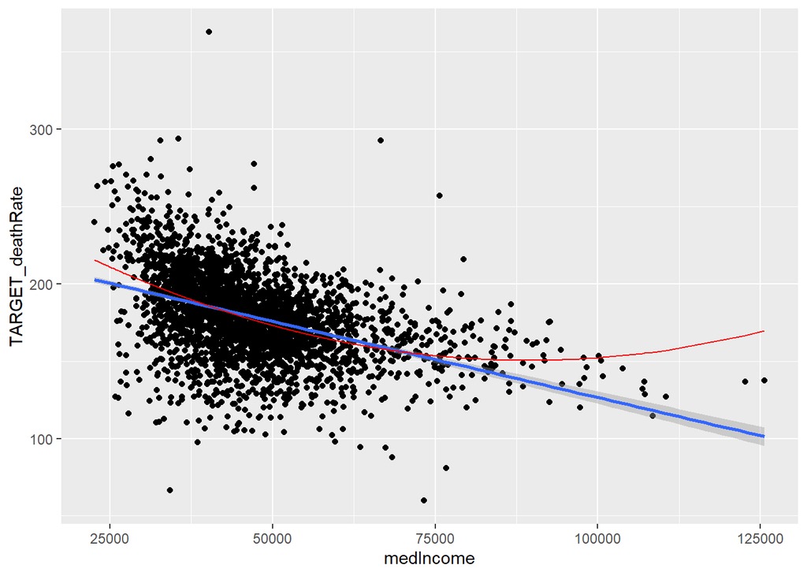

```r
predict = data.frame(TARGET_deathRate = predict(mod1.6.1, dat), medIncome = dat$medIncome)

dat %>% ggplot(aes(medIncome, TARGET_deathRate)) + geom_point() + geom_smooth(method = "lm") + geom_line(data = predict, aes(medIncome,TARGET_deathRate ), color = "red")
```

Judging from summary output, the quadratic model performs better than the purely linear model (based on adjusted R-squared value) and the two models are statistically different. However, a visual inspection of the data doesn’t really show that the quadratic model is significantly better. At this point, we decide to keep the quadratic term due to the diagnostic stats.

We now have this following core model:

```r
mod1_core = lm(data = dat, TARGET_deathRate ~ medIncome + I(medIncome ^2)+ PctWhite + PctAsian + PctOtherRace)
summary(mod1_core)
```

```
##
## Call:
## lm(formula = TARGET_deathRate ~ medIncome + I(medIncome^2) +
##     PctWhite + PctAsian + PctOtherRace, data = dat)
##
## Residuals:
##      Min       1Q   Median       3Q      Max
## -121.247  -13.750    1.302   14.195  174.871
##
## Coefficients:
##                  Estimate Std. Error t value Pr(>|t|)
## (Intercept)     2.756e+02  4.938e+00  55.821  < 2e-16 ***
## medIncome      -2.159e-03  1.885e-04 -11.456  < 2e-16 ***
## I(medIncome^2)  1.182e-08  1.656e-09   7.141 1.16e-12 ***
## PctWhite       -2.362e-01  3.095e-02  -7.632 3.08e-14 ***
## PctAsian       -5.664e-01  2.032e-01  -2.787  0.00535 **
## PctOtherRace   -1.419e+00  1.303e-01 -10.884  < 2e-16 ***
## ---
## Signif. codes:  0 '***' 0.001 '**' 0.01 '*' 0.05 '.' 0.1 ' ' 1
##
## Residual standard error: 24.14 on 3011 degrees of freedom
## Multiple R-squared:  0.2437, Adjusted R-squared:  0.2424
## F-statistic:   194 on 5 and 3011 DF,  p-value: < 2.2e-16
```

let’s evaluate the residual diagnostic to confirm the model’s validity.

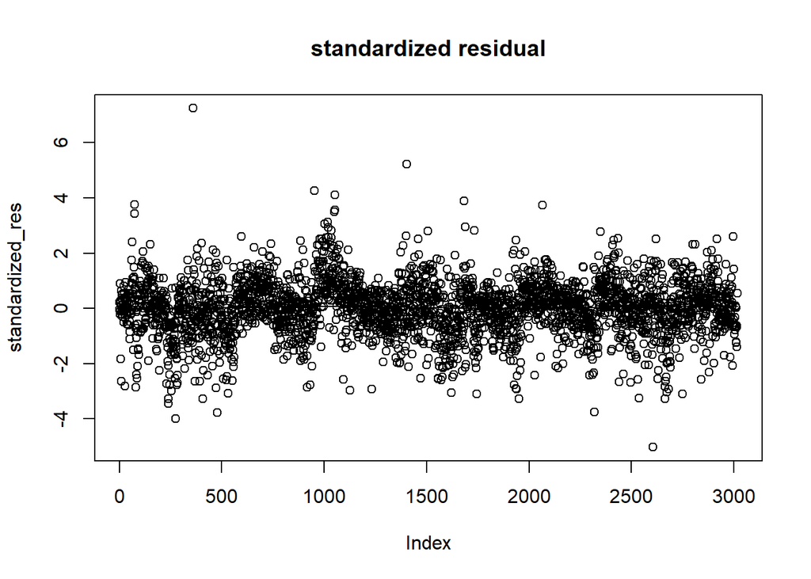

```r
standardized_res = rstandard(mod1_core)
scatter.smooth(standardized_res, main = "standardized residual")
```

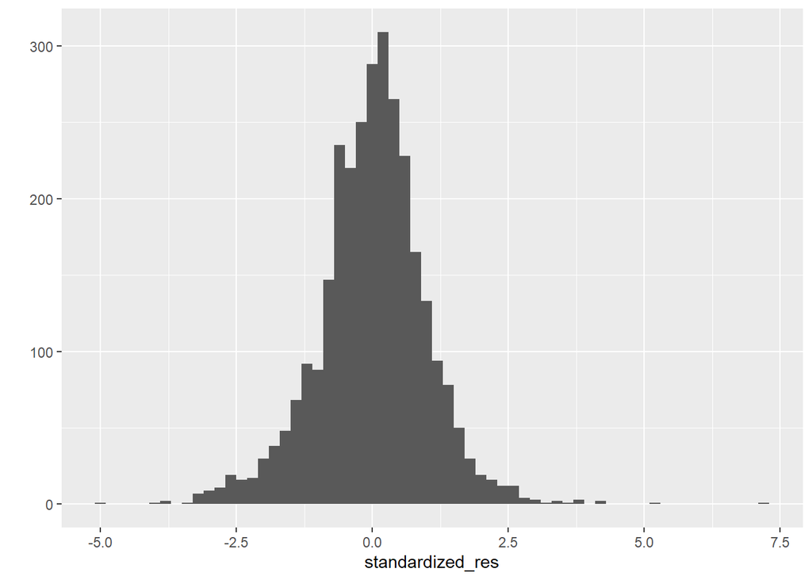

```r
qplot(standardized_res, binwidth = 0.2)
```

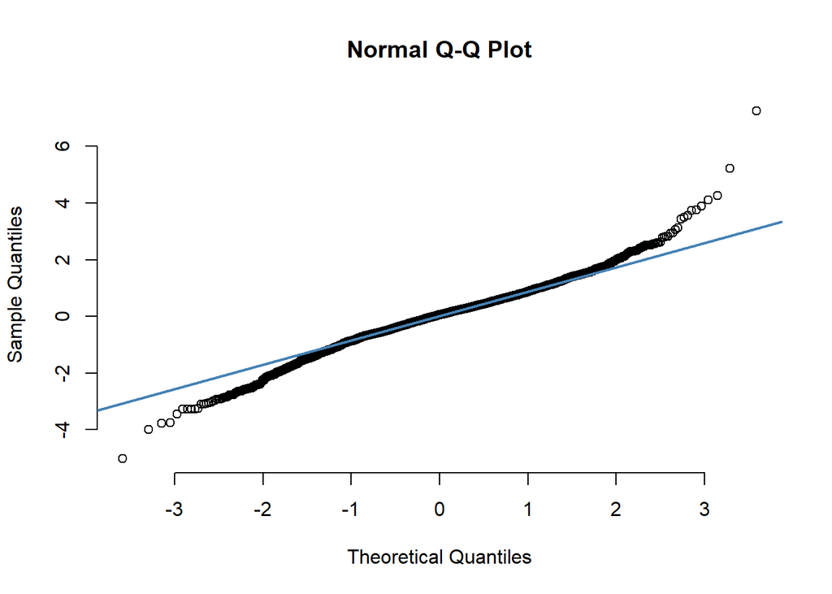

```r
qqnorm(standardized_res, pch = 1, frame = FALSE)
qqline(standardized_res, col = "steelblue", lwd = 2)
```

The model looks good, and the qqplot of the standardized residual plot only deviates from the straight line at the two edges. Thus, in conclusion, our core model is a good place to start for our future work.

#### future work and direction

As mentioned in the missing data section, the education data is largely missing and we weren’t able to directly add them to our analysis. We have acquired further information on the education level of each US county (data sourced from a 2020 study). However, the integration of the new data into our data set requires additional cleaning and this process will be conducted at a later time point. Furthermore, we are also looking to incorporate the insurance information of the US counties into the linear model.

We are considering using GAM models in our future exploration as well. Using different smoothing methods could improve the performance of our models, and we are definitely interested in testing them out.

After we include all of the variables that we are interested in, we will preform Lasso, ridge, and elastic net models to reduce the overfitting and deciding on our final linear model. As we increase the number of predictor variables, we are expecting that some of them might be excluded from the final model during the either the lasso or the elastic net fitting process.

### b. Logistic/multinomial/ordinal regression

Logistic/multinomial/ordinaln does not really fit into the exploration of our primary goals, as the lung-cancer death count can be mostly view as either a count statistics or a continuous outcome. However, there are several thing that we could do to incorporate Logistic/multinomial/ordinal regression into our project.

First, we can split the lung-cancer death rate into several categories to broadly access the healthcare system at each county. For example, we can artificially create three different categories in the death rate variable. Let’s take a look at the death rate distribution.

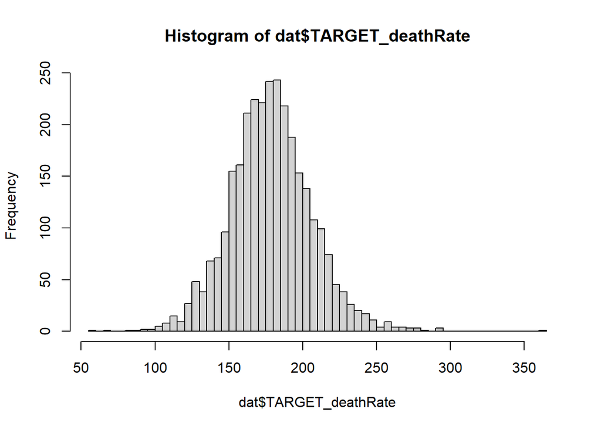

```r
hist(dat$TARGET_deathRate, breaks = 100)
```

We can make three bins, deathrate < 150, 150 <= deathrate < 200, 200 <= deathrate, and use them as a proxy to the quality of lung cancer prevention and quality of cancer care for each US county. But in fairness, the use of logistic regression in this case wouldn’t benefit us too much as it doesn’t really bring any new insight to our analysis. The previous linear model already provides a fine baseline in assess the same information for each US county. The normal distribution of lung cancer death rate also suggests that dividing outcomes into bins doesn’t really benefit us with our primary goal.

But let’s do it anyway to test it out anyway.

```r
#create the three bins
dat = dat %>% mutate(multi = case_when(TARGET_deathRate < 150 ~ 1, TARGET_deathRate < 200 ~ 2, T ~ 3))
# 3 is bad quality lung cancer prevention, 2 is medium, 1 is good quality.
```

```r
library(nnet)
mod2.1 <- multinom(multi ~ medIncome + I(medIncome ^2), data = dat)
summary(mod2.1)
```

```
## Call:
## multinom(formula = multi ~ medIncome + I(medIncome^2), data = dat)
##
## Coefficients:
##    (Intercept)    medIncome I(medIncome^2)
## 2 2.417464e-09 9.165115e-05  -1.083448e-09
## 3 7.931352e-09 1.565121e-04  -3.185035e-09
##
## Std. Errors:
##    (Intercept)    medIncome I(medIncome^2)
## 2 6.249523e-21 2.523511e-16   1.799483e-11
## 3 1.659987e-20 7.128037e-16   3.143898e-11
##
## Residual Deviance: 4632.192
## AIC: 4644.192
```

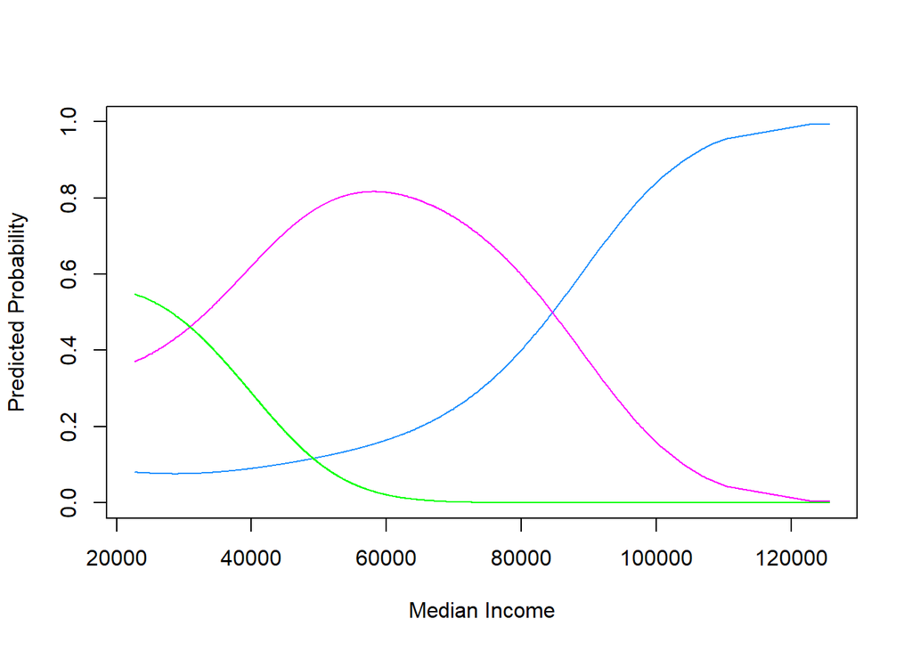

```r
plot(mod2.1$fitted.values[,1][order(dat$medIncome)] ~ sort(dat$medIncome), type="l", col="dodgerblue", xlab=c("Median Income"), ylab="Predicted Probability", ylim=c(0,1))
points(mod2.1$fitted.values[,2][order(dat$medIncome)] ~ sort(dat$medIncome), type="l", col="magenta")
points(mod2.1$fitted.values[,3][order(dat$medIncome)]~sort(dat$medIncome), type="l", col="green")
```

we see that as median income increases, the county is much more likely to fall into the category 1, which is county with low lung cancer death rate. We can do the same with percentage of white citizens in the county as well.

```r
mod2.2 <- multinom(multi ~ PctWhite , data = dat)
summary(mod2.2)
```

```
## Call:
## multinom(formula = multi ~ PctWhite, data = dat)
##
## Coefficients:
##   (Intercept)     PctWhite
## 2    2.241079 -0.007027921
## 3    2.609593 -0.026135639
##
## Std. Errors:
##   (Intercept)    PctWhite
## 2   0.3398884 0.003901638
## 3   0.3612030 0.004210873
##
## Residual Deviance: 5105.871
## AIC: 5113.871
```

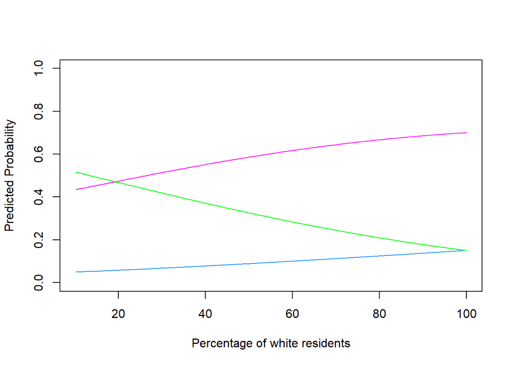

```r
plot(mod2.2$fitted.values[,1][order(dat$PctWhite)] ~ sort(dat$PctWhite), type="l", col="dodgerblue", xlab=c("Percentage of white residents"), ylab="Predicted Probability", ylim=c(0,1))
points(mod2.2$fitted.values[,2][order(dat$PctWhite)] ~ sort(dat$PctWhite), type="l", col="magenta")
points(mod2.2$fitted.values[,3][order(dat$PctWhite)]~sort(dat$PctWhite), type="l", col="green")
```

We see that percentage of white resident has less impact on the categorization of the county.

However, we can see that this type of multinomial regression is less interesting than the linear model, as we are grossly categorizing the outcome variables. Thus, we have decided to take the logistic regression to another direction. Logistic regression could serve as an excellent method for the exploration of our secondary goals.

One possible direction that we could take is to explore socioeconomic status and political tendencies. The US bipartisan system provides a excellent binary outcome for our logistic models. We could decide whether what would drive the county to vote for either candidates. To explore this topic, we would need to find additional data on the voting outcomes of 2016 on a county level and merge with our existing data set. This exploration will have to be conducted at a later time after we find a trustworthy and accurate data source. Currently, the politico site serves as the preliminary source for our data as it contains detailed county level voting outcomes. Source: https://www.politico.com/2016-election/results/map/president/.

Additional data wrangling is required before we move forward with the Logistic/multinomial/ordinal regression analysis. Our current plan for the regressions invovles using the covariates from the previous linear models and develop our model from there. We think that the logistic regression model would be helpful in showing the political preference of different demographic groups.

### Over-dispersion

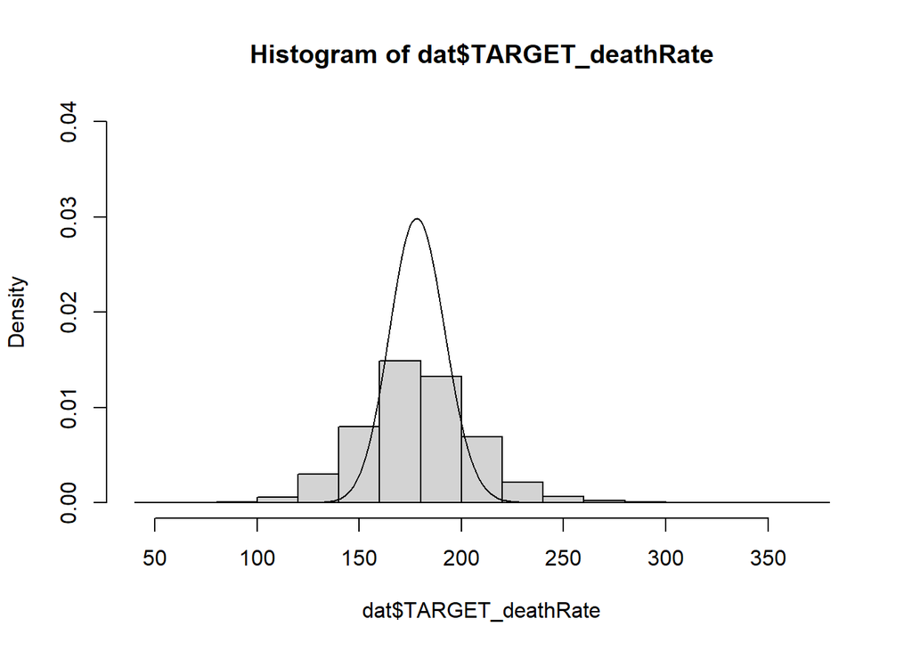

```r
hist(dat$TARGET_deathRate, freq = F, ylim = c(0, 0.04))
lines(as.integer(min(dat$TARGET_deathRate)):as.integer(max(dat$TARGET_deathRate)), dpois(as.integer(min(dat$TARGET_deathRate)):as.integer(max(dat$TARGET_deathRate)), lambda = mean(dat$TARGET_deathRate)))
```

```r
print(mean(dat$TARGET_deathRate))
```

```
## [1] 178.6452
```

```r
print(var(dat$TARGET_deathRate))
```

```
## [1] 769.2961
```

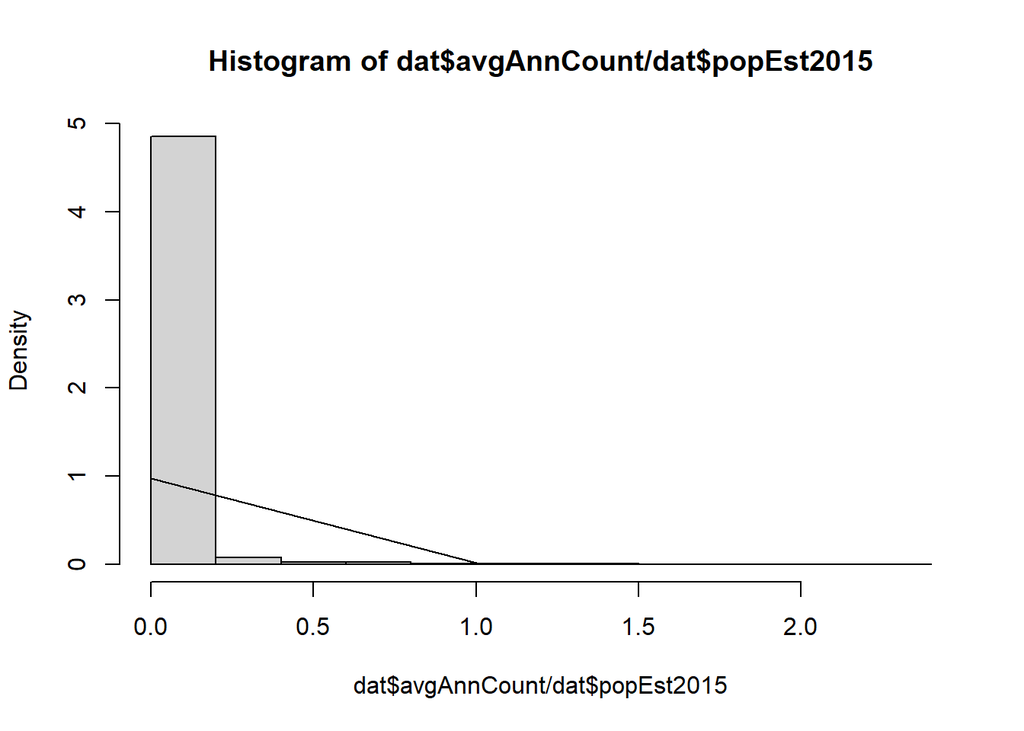

```r
hist(dat$avgAnnCount/dat$popEst2015, freq = F)#, ylim = c(0, 0.04))
lines(as.integer(min(dat$avgAnnCount/dat$popEst2015)):as.integer(max(dat$avgAnnCount/dat$popEst2015)), dpois(as.integer(min(dat$avgAnnCount/dat$popEst2015)):as.integer(max(dat$avgAnnCount/dat$popEst2015)), lambda = mean(dat$avgAnnCount/dat$popEst2015)))
```

```r
mean(dat$avgDeathsPerYear/dat$popEst2015)
```

```
## [1] 0.002287129
```

```r
var(dat$avgDeathsPerYear/dat$popEst2015)
```

```
## [1] 3.729806e-07
```

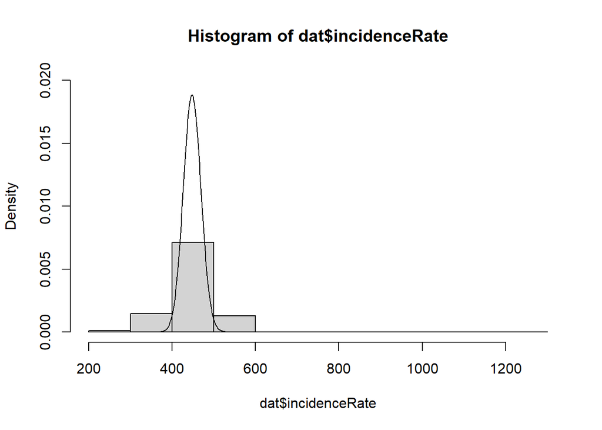

```r
hist(dat$incidenceRate, freq = F, ylim = c(0, 0.02))
lines(as.integer(min(dat$incidenceRate)):as.integer(max(dat$incidenceRate)), dpois(as.integer(min(dat$incidenceRate)):as.integer(max(dat$incidenceRate)), lambda = mean(dat$incidenceRate)))
```

```r
print(mean(dat$incidenceRate))
```

```
## [1] 448.1764
```

```r
print(var(dat$incidenceRate))
```

```
## [1] 2982.145
```

We would not need to modify our data at all to perform a Negative Binomial regression as our data is already in counts or rate form. Although one potential modification we might do is see how the regression turns out modelling the rate per 100 000 (our target of interest), and the pure count itself adjusting for population.

### Model fits

```r
# poisson fit
state_inc_pop_pois <- dat %>% glm(formula = TARGET_deathRate ~ medIncome + State + popEst2015, family=poisson(), data=.)
summary(state_inc_pop_pois)
```

```
##
## Call:
## glm(formula = TARGET_deathRate ~ medIncome + State + popEst2015,
##     family = poisson(), data = .)
##
## Deviance Residuals:
##     Min       1Q   Median       3Q      Max
## -9.7899  -0.9173   0.0055   0.9062  11.6936
##
## Coefficients:
##               Estimate Std. Error z value Pr(>|z|)
## (Intercept)  5.548e+00  1.957e-02 283.437  < 2e-16 ***
## medIncome   -4.502e-06  1.435e-07 -31.378  < 2e-16 ***
## StateAL     -1.111e-01  1.995e-02  -5.571 2.54e-08 ***
## StateAR     -7.953e-02  1.958e-02  -4.062 4.86e-05 ***
## StateAZ     -3.451e-01  2.765e-02 -12.482  < 2e-16 ***
## StateCA     -2.272e-01  2.063e-02 -11.015  < 2e-16 ***
## StateCO     -3.604e-01  2.065e-02 -17.454  < 2e-16 ***
## StateCT     -1.658e-01  3.318e-02  -4.998 5.78e-07 ***
## StateDC     -1.967e-02  5.528e-02  -0.356 0.722031
## StateDE     -9.943e-02  4.658e-02  -2.134 0.032813 *
## StateFL     -1.562e-01  1.995e-02  -7.829 4.90e-15 ***
## StateGA     -1.527e-01  1.871e-02  -8.160 3.35e-16 ***
## StateHI     -3.009e-01  4.533e-02  -6.637 3.19e-11 ***
## StateIA     -2.000e-01  1.917e-02 -10.433  < 2e-16 ***
## StateID     -3.036e-01  2.154e-02 -14.092  < 2e-16 ***
## StateIL     -1.067e-01  1.901e-02  -5.612 2.00e-08 ***
## StateIN     -8.772e-02  1.911e-02  -4.589 4.46e-06 ***
## StateKS     -2.028e-01  1.914e-02 -10.591  < 2e-16 ***
## StateKY      6.348e-04  1.881e-02   0.034 0.973082
## StateLA     -7.386e-02  1.984e-02  -3.723 0.000197 ***
## StateMA     -1.453e-01  2.723e-02  -5.335 9.54e-08 ***
## StateMD     -7.295e-02  2.326e-02  -3.136 0.001710 **
## StateME     -1.317e-01  2.552e-02  -5.161 2.45e-07 ***
## StateMI     -1.645e-01  1.948e-02  -8.443  < 2e-16 ***
## StateMN     -2.181e-01  1.941e-02 -11.237  < 2e-16 ***
## StateMO     -1.165e-01  1.896e-02  -6.144 8.04e-10 ***
## StateMS     -7.530e-02  1.948e-02  -3.864 0.000111 ***
## StateMT     -2.559e-01  2.101e-02 -12.182  < 2e-16 ***
## StateNC     -1.783e-01  1.928e-02  -9.248  < 2e-16 ***
```

[output cut: 19 more lines]

```
## StateWA     -2.024e-01  2.149e-02  -9.420  < 2e-16 ***
## StateWI     -1.687e-01  1.968e-02  -8.569  < 2e-16 ***
## StateWV     -8.860e-02  2.018e-02  -4.390 1.13e-05 ***
## StateWY     -2.220e-01  2.404e-02  -9.235  < 2e-16 ***
## popEst2015  -1.060e-08  4.808e-09  -2.205 0.027479 *
## ---
## Signif. codes:  0 '***' 0.001 '**' 0.01 '*' 0.05 '.' 0.1 ' ' 1
##
## (Dispersion parameter for poisson family taken to be 1)
##
##     Null deviance: 13026.8  on 3016  degrees of freedom
## Residual deviance:  7555.3  on 2964  degrees of freedom
## AIC: Inf
##
## Number of Fisher Scoring iterations: 4
```

```r
# neg bin fit
state_inc_pop_nb <- dat %>% MASS::glm.nb(formula = TARGET_deathRate ~ medIncome + State + popEst2015, data=.)
summary(state_inc_pop_nb)
```

```
##
## Call:
## MASS::glm.nb(formula = TARGET_deathRate ~ medIncome + State +
##     popEst2015, data = ., init.theta = 118.3508188, link = log)
##
## Deviance Residuals:
##     Min       1Q   Median       3Q      Max
## -6.7153  -0.5830   0.0045   0.5662   6.8103
##
## Coefficients:
##               Estimate Std. Error z value Pr(>|z|)
## (Intercept)  5.542e+00  3.153e-02 175.761  < 2e-16 ***
## medIncome   -4.428e-06  2.224e-07 -19.913  < 2e-16 ***
## StateAL     -1.088e-01  3.236e-02  -3.361 0.000776 ***
## StateAR     -7.718e-02  3.182e-02  -2.426 0.015280 *
## StateAZ     -3.421e-01  4.296e-02  -7.963 1.68e-15 ***
## StateCA     -2.255e-01  3.298e-02  -6.837 8.11e-12 ***
## StateCO     -3.588e-01  3.273e-02 -10.964  < 2e-16 ***
## StateCT     -1.662e-01  5.159e-02  -3.221 0.001277 **
## StateDC     -1.972e-02  8.826e-02  -0.223 0.823198
## StateDE     -9.806e-02  7.408e-02  -1.324 0.185601
## StateFL     -1.549e-01  3.222e-02  -4.808 1.52e-06 ***
## StateGA     -1.501e-01  3.030e-02  -4.954 7.28e-07 ***
## StateHI     -3.001e-01  6.833e-02  -4.392 1.12e-05 ***
## StateIA     -1.985e-01  3.091e-02  -6.422 1.34e-10 ***
## StateID     -3.020e-01  3.423e-02  -8.822  < 2e-16 ***
## StateIL     -1.046e-01  3.078e-02  -3.399 0.000676 ***
## StateIN     -8.608e-02  3.099e-02  -2.778 0.005476 **
## StateKS     -2.014e-01  3.088e-02  -6.521 6.97e-11 ***
## StateKY      2.029e-03  3.063e-02   0.066 0.947177
## StateLA     -7.152e-02  3.223e-02  -2.219 0.026472 *
## StateMA     -1.436e-01  4.300e-02  -3.339 0.000842 ***
## StateMD     -7.193e-02  3.733e-02  -1.927 0.053977 .
## StateME     -1.299e-01  4.107e-02  -3.163 0.001559 **
## StateMI     -1.627e-01  3.147e-02  -5.169 2.36e-07 ***
## StateMN     -2.161e-01  3.120e-02  -6.925 4.35e-12 ***
## StateMO     -1.144e-01  3.073e-02  -3.723 0.000197 ***
## StateMS     -7.231e-02  3.167e-02  -2.283 0.022432 *
## StateMT     -2.536e-01  3.359e-02  -7.548 4.43e-14 ***
## StateNC     -1.760e-01  3.116e-02  -5.650 1.61e-08 ***
```

[output cut: 25 more lines]

```
## Signif. codes:  0 '***' 0.001 '**' 0.01 '*' 0.05 '.' 0.1 ' ' 1
##
## (Dispersion parameter for Negative Binomial(118.3508) family taken to be 1)
##
##     Null deviance: 5232.5  on 3016  degrees of freedom
## Residual deviance: 3051.8  on 2964  degrees of freedom
## AIC: 27080
##
## Number of Fisher Scoring iterations: 1
##
##
##               Theta:  118.35
##           Std. Err.:  5.12
##
##  2 x log-likelihood:  -26971.87
```

### d. Survival Analysis

We are not going to incorporate survival analysis into our project. This is because we do not have any time-to-event related relationships in our data. Furthermore, we cannot really reproduce these relationships using a modification of our variables since they are all aggregates over a time period, and so we cannot infer the individual-level observations to re-create time-to-event data.

## Abstract

Lung cancer is one of the leading causes of global cancer incidence and mortality, accumulating over 1.8 million deaths each year. Lung cancer has become the second most common forms of cancer diagnosis for both men and women (Thandra et al). Although the incidence rate and mortality rate of lung cancer has been decreasing in the US due to public education and tobacco control policies (De groot et al), a better understanding of the disease within the socialeconomic and demographic context is still required to provide future guidance on combating the prevalent form of cancer. Data from US census, county level reports, and various government agencies were collected to create tabular data on lung cancer death rate, social economic status, demographic information, education level, and medical insurance information on the US county level. The primary goal of the project is to create a explanatory model between social economic status and the lung cancer death rate of each US county. A secondary goal of this project is to predict the political inclination of each county base on the existing data set using logistic regression models.

Citations:

1. Thandra, Krishna Chaitanya et al. “Epidemiology of lung cancer.” Contemporary oncology (Poznan, Poland) vol. 25,1 (2021): 45-52. doi:10.5114/wo.2021.103829
2. de Groot, P. M., Wu, C. C., Carter, B. W., & Munden, R. F. (2018). The epidemiology of lung cancer. Translational lung cancer research, 7(3), 220–233. https://doi.org/10.21037/tlcr.2018.05.06